# Unsupervised Learning: Trade&Ahead

### Creating Final HC Model

```python
HCmodel = AgglomerativeClustering(n_clusters=6, affinity="euclidean", linkage="ward")
HCmodel.fit(hc_df)
```

```
AgglomerativeClustering(affinity='euclidean', n_clusters=6)
```

```python
hc_df["HC_Clusters"] = HCmodel.labels_
df1["HC_Clusters"] = HCmodel.labels_
```

```python
cluster_profile = df1.groupby("HC_Clusters").mean()
```

```python
cluster_profile["count_in_each_segments"] = (
    df1.groupby("HC_Clusters")["Security"].count().values
)
```

```python
# let's see the names of the securities in each cluster
for cl in df1["HC_Clusters"].unique():
    print(
        "The",
        df1[df1["HC_Clusters"] == cl]["Security"].nunique(),
        "Securities in cluster",
        cl,
        "are:",
    )
    print(df1[df1["HC_Clusters"] == cl]["Security"].unique())
    print("-" * 100, "\n")
```

```
The 275 Securities in cluster 3 are:
['American Airlines Group' 'AbbVie' 'Abbott Laboratories'
 'Analog Devices, Inc.' 'Archer-Daniels-Midland Co' 'Ameren Corp'
 'American Electric Power' 'AFLAC Inc'
 'American International Group, Inc.' 'Apartment Investment & Mgmt'
 'Assurant Inc' 'Arthur J. Gallagher & Co.' 'Akamai Technologies Inc'
 'Albemarle Corp' 'Alaska Air Group Inc' 'Allstate Corp' 'AMETEK Inc'
 'Affiliated Managers Group Inc' 'Ameriprise Financial'
 'American Tower Corp A' 'AutoNation Inc' 'Anthem Inc.' 'Aon plc'
 'Amphenol Corp' 'Arconic Inc' 'Activision Blizzard'
 'AvalonBay Communities, Inc.' 'American Water Works Company Inc'
 'American Express Co' 'Boeing Company' 'Baxter International Inc.'
 'BB&T Corporation' 'Bard (C.R.) Inc.' 'BIOGEN IDEC Inc.'
 'The Bank of New York Mellon Corp.' 'Ball Corp' 'Bristol-Myers Squibb'
 'Boston Scientific' 'BorgWarner' 'Boston Properties' 'Caterpillar Inc.'
 'Chubb Limited' 'CBRE Group' 'Crown Castle International Corp.'
 'Carnival Corp.' 'CF Industries Holdings Inc' 'Citizens Financial Group'
 'Church & Dwight' 'C. H. Robinson Worldwide' 'CIGNA Corp.'
 'Cincinnati Financial' 'Comerica Inc.' 'CME Group Inc.' 'Cummins Inc.'
 'CMS Energy' 'Centene Corporation' 'CenterPoint Energy'
 'Capital One Financial' 'The Cooper Companies' 'CSX Corp.'
 'CenturyLink Inc' 'Cognizant Technology Solutions' 'Citrix Systems'
 'CVS Health' 'Chevron Corp.' 'Dominion Resources' 'Delta Air Lines'
 'Du Pont (E.I.)' 'Deere & Co.' 'Discover Financial Services'
 'Quest Diagnostics' 'Danaher Corp.' 'The Walt Disney Company'
 'Discovery Communications-A' 'Discovery Communications-C'
 'Delphi Automotive' 'Digital Realty Trust' 'Dun & Bradstreet'
 'Dover Corp.' 'Dr Pepper Snapple Group' 'Duke Energy' 'DaVita Inc.'
 'eBay Inc.' 'Ecolab Inc.' 'Consolidated Edison' 'Equifax Inc.'
 "Edison Int'l" 'Eastman Chemical' 'Equity Residential' 'EQT Corporation'
 'Eversource Energy' 'Essex Property Trust, Inc.' 'E*Trade'
 'Eaton Corporation' 'Entergy Corp.' 'Exelon Corp.' "Expeditors Int'l"
 'Expedia Inc.' 'Extra Space Storage' 'Fastenal Co'
 'Fortune Brands Home & Security' 'FirstEnergy Corp'
 'Fidelity National Information Services' 'Fiserv Inc' 'FLIR Systems'
 'Fluor Corp.' 'Flowserve Corporation' 'FMC Corporation'
 'Federal Realty Investment Trust' 'General Dynamics'
 'General Growth Properties Inc.' 'Gilead Sciences' 'Corning Inc.'
 'General Motors' 'Genuine Parts' 'Garmin Ltd.' 'Goodyear Tire & Rubber'
 'Grainger (W.W.) Inc.' 'Halliburton Co.' 'Hasbro Inc.'
```

[output cut: 72 more lines]

```
The 22 Securities in cluster 4 are:
['Anadarko Petroleum Corp' 'Baker Hughes Inc' 'Cabot Oil & Gas'
 'Concho Resources' 'Devon Energy Corp.' 'EOG Resources'
 'Freeport-McMoran Cp & Gld' 'Hess Corporation' 'Kinder Morgan'
 'Marathon Oil Corp.' 'Murphy Oil' 'Noble Energy Inc'
 'Newfield Exploration Co' 'National Oilwell Varco Inc.' 'ONEOK'
 'Occidental Petroleum' 'Range Resources Corp.' 'Spectra Energy Corp.'
 'Southwestern Energy' 'Teradata Corp.' 'Williams Cos.' 'Cimarex Energy']
----------------------------------------------------------------------------------------------------

The 9 Securities in cluster 5 are:
['Citigroup Inc.' 'Ford Motor' 'JPMorgan Chase & Co.' 'Coca Cola Company'
 'Pfizer Inc.' 'AT&T Inc' 'Verizon Communications' 'Wells Fargo'
 'Exxon Mobil Corp.']
----------------------------------------------------------------------------------------------------
```

Observations: This looks better! Our clusters have more securities and more variability.

```python
# lets display cluster profile
cluster_profile.style.highlight_max(color="lightgreen", axis=0)
```

| HC_Clusters | Current Price | Price Change | Volatility | ROE | Cash Ratio | Net Cash Flow | Net Income | Earnings Per Share | Estimated Shares Outstanding | P/E Ratio | P/B Ratio | count_in_each_segments |
| --- | --- | --- | --- | --- | --- | --- | --- | --- | --- | --- | --- | --- |
| 0 | 152.566666 | 14.908086 | 1.769506 | 24.434783 | 281.913043 | 1747221304.347826 | 1866621956.521739 | 3.802174 | 759756952.867391 | 38.674023 | 16.027369 | 23 |
| 1 | 84.355716 | 3.854981 | 1.827670 | 633.571429 | 33.571429 | -568400000.000000 | -4968157142.857142 | -10.841429 | 398169036.442857 | 42.284541 | -11.589502 | 7 |
| 2 | 563.992491 | 17.235667 | 1.839399 | 10.250000 | 125.500000 | 105834000.000000 | 853500250.000000 | 13.085000 | 287806305.492500 | 307.105187 | -4.254889 | 4 |
| 3 | 72.421687 | 4.563230 | 1.403434 | 25.218182 | 55.014545 | 72801872.727273 | 1572467469.090909 | 3.728564 | 445003946.148764 | 24.188244 | -2.966949 | 275 |
| 4 | 36.440455 | -16.073408 | 2.832884 | 57.500000 | 42.409091 | -472834090.909091 | -3161045227.272727 | -8.005000 | 514367806.201818 | 85.555682 | 0.836839 | 22 |
| 5 | 46.672222 | 5.166566 | 1.079367 | 25.000000 | 58.333333 | -3040666666.666667 | 14848444444.444445 | 3.435556 | 4564959946.222222 | 15.596051 | -6.354193 | 9 |

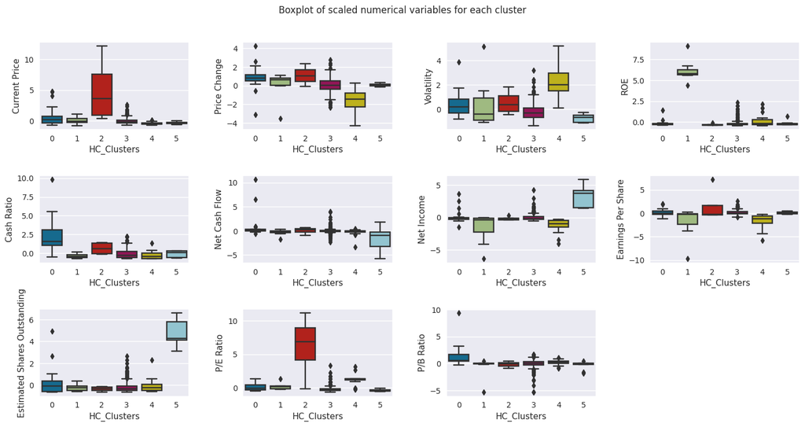

```python
plt.figure(figsize=(15, 10))
plt.suptitle("Boxplot of scaled numerical variables for each cluster", fontsize=12)

for i, variable in enumerate(num_col):
    plt.subplot(4, 4, i + 1)
    sns.boxplot(data=hc_df, x="HC_Clusters", y=variable)

plt.tight_layout(pad=2.0)
```

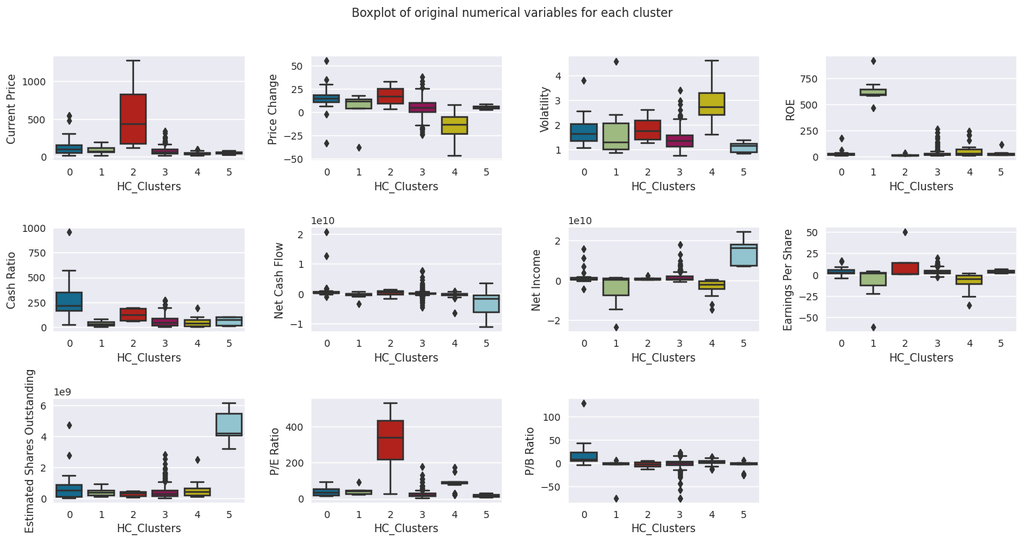

```python
plt.figure(figsize=(15, 10))
plt.suptitle("Boxplot of original numerical variables for each cluster", fontsize=12)

for i, variable in enumerate(num_col):
    plt.subplot(4, 4, i + 1)
    sns.boxplot(data=df1, x="HC_Clusters", y=variable)

plt.tight_layout(pad=2.0)
```

Key Insights by Cluster

**Cluster 0:**

- Cash Ratio is highest
- Price Change is high

**Cluster 1:**

- Net Income is lowest
- Earnings per Share is lowest

**Cluster 2:**

- P/E Ratio is highest
- Current Price is highest

**Cluster 3:**

- All variables seem to be very middle of the road
- Most variables tend to have quite a few outliers

**Cluster 4:**

- Price Change is at a minimum
- Earnings per Share are low
- Volatility is highest

**Cluster 5:**

- Estimated Shares Outstanding are the highest
- Volatility is lowest

## K-means vs Hierarchical Clustering

You compare several things, like:

- Which clustering technique took less time for execution?
- Which clustering technique gave you more distinct clusters, or are they the same?
- How many observations are there in the similar clusters of both algorithms?
- How many clusters are obtained as the appropriate number of clusters from both algorithms?

You can also mention any differences or similarities you obtained in the cluster profiles from both the clustering techniques.

Observations:

- With K-Means Clustering, we ended up with 4 clusters, whereas with Hierarchical Clustering we ended up with 6.
- Both techniques were relatively quick to execute, but I preferred the more 'data-driven' approach with the Hierarchical Clustering. The elbow graph was tough to find the right number for K in K-Means, and the Silhouette coefficients all seemed to be fairly close as well. I much prefer the more concrete number of clusters show in the dendograms vs having to guess.
- In both methods we ended up seeing a large # of securities falling into one of the clusters.
- We see a lot of the same securities in Cluster 3 from K-Means as we see in Cluster 5 of Hierarchical Clustering (AT&T, Verizon, Citigroup, etc)

## Actionable Insights and Recommendations

Since the goal of investing is to maximize return on investment while mininiizing risk, I would recommend that Trade&Ahead create balanced portfolios using the clusters we have created. They can do so by recommending a portfolio have 1 or more securities from each of the clusters. Since the Hierarchical Approach lead us to have 6 clusters vs just 4, that could potentially balance the portfolio even better and I would suggest they favor those clusters.

For investors who may prefer higher reward, they will need to be prepared to take higher risks, and their portfolio could have more stocks from cluster 2 with a higher current price and higher P/E.

For investors who may not have as much money to invest, they may want their portfolio to have more stocks from clusters 4 & 5, which seem to be sold at a lower current price for the most part.

Depending on the profile of the investor, how much risk they are willing to take on, how much money they have to invest, what stage of their life they are at, etc. Trade&Ahead can use our clusters to create a customized portfolio that is balanced to meet their needs.